# Template Designer for ENM

#### How to design a template that fits your data

- Navigate to the [**template designer**](https://enanomapper.adma.ai/templates) of Momentum
- Click on “**Create new draft**”
- Can also browse **Finalized** and **Draft Blueprints** to see templates designed by others

When creating a new draft, a sequence of sheets pops up that need to be populated with information about your data.

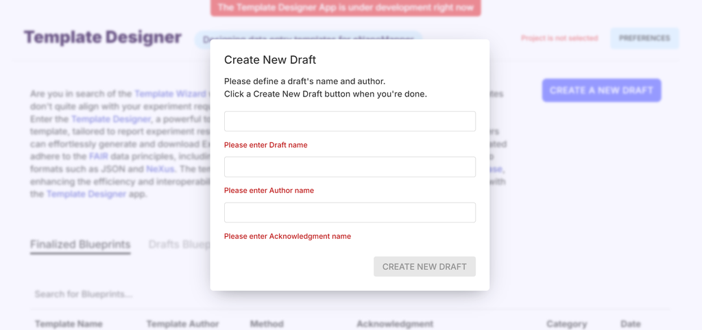

Please *provide a name* for your template, your name as author and your affiliation or project for the acknowledgement.

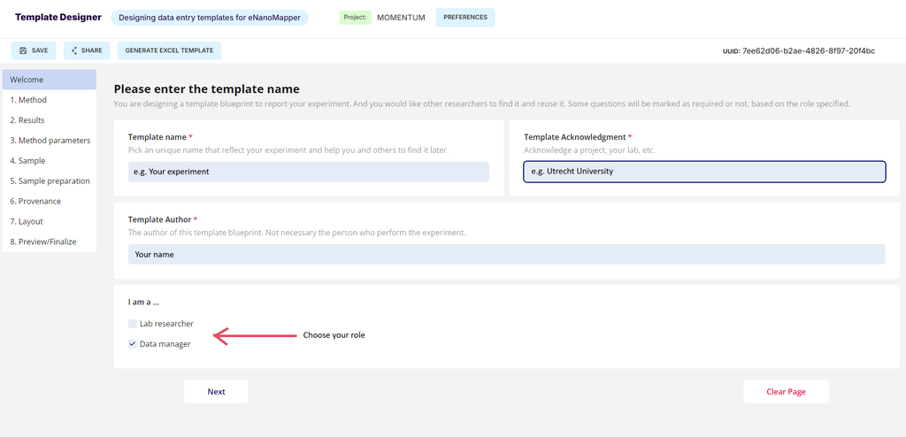

*Choose your role*. Drafts can only be finalized if “*data manager*” is chosen, however, templates are **still functioning** when they are not finalized.

Please remember that you can always reach out to a data steward at your institute or the responsible person at UU.

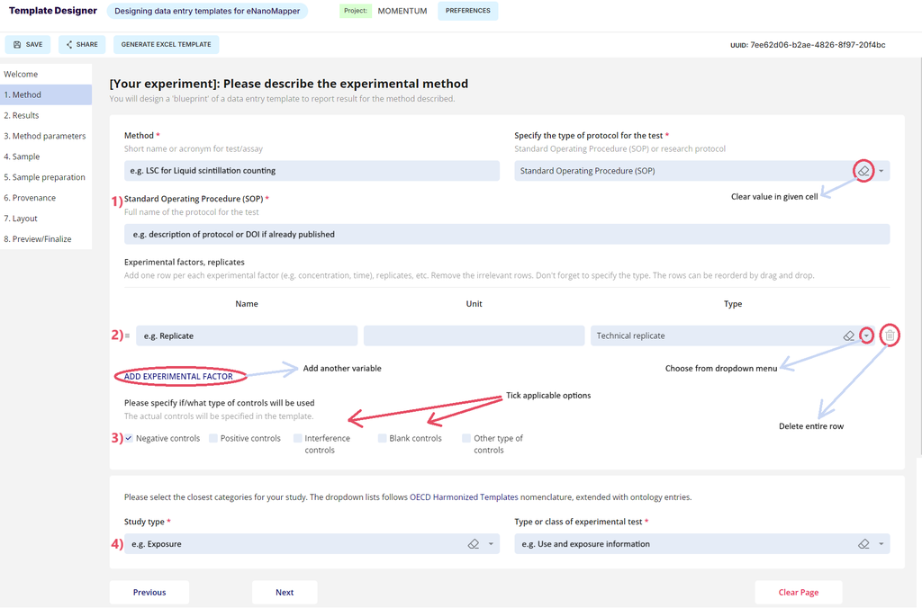

You can *link to your SOP*.

1. Please provide a DOI in case it is published already and/or describe your protocol.
2. List and specify your *experimental factors*, for instance: dose, time of measurement, replicates, compartment measured etc. Think of variables that are known beforehand and varied intentionally.
3. Tick the applicable *controls* as well.
4. Choose a study *type* and *class* of experiment that is most fitting.

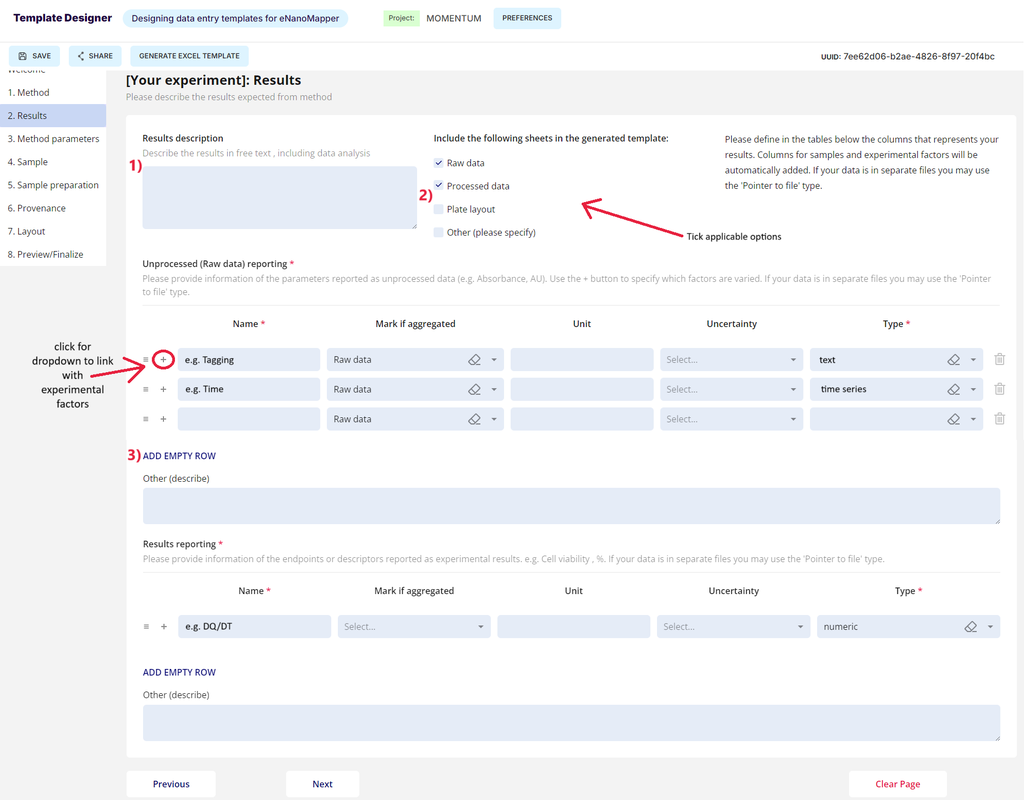

In the Results tab you can choose what *output you would like to report*.

1. Please *describe* your results.
2. Choose all applicable options for *type of data* you want to make available. The category “Other” will not generate a sheet in your excel template though.
3. Please fill in *variables* you want to report (in the example on the screenshot, raw and processed data is made available).

Think of for instance:

- absorbance as raw data
- cell viability and fold change as processed data.

Clicking on the little cross in front of variables, you can specify which experimental conditions refer to your reported results.

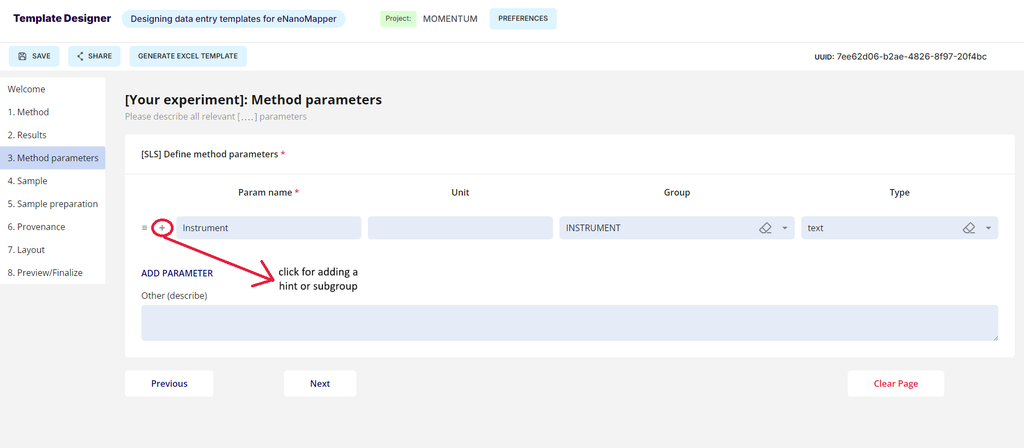

List your *method parameters*.

You can think of for instance: cell line details, culture conditions, information on the medium, environment etc.

You can provide hints about your variables if you click the little cross in front of the parameter names.

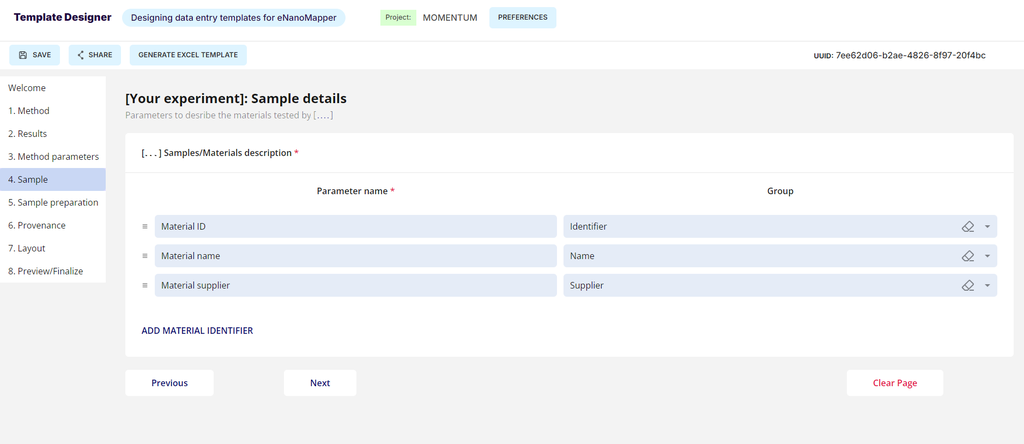

The sample fields will largely be ignored so you can leave this tab as is. The material sheet is uniform across templates.

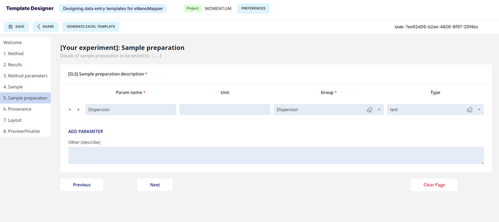

List applicable variables for your *sample preparation*.

You can think of for instance: dispersion and dispersion agent.

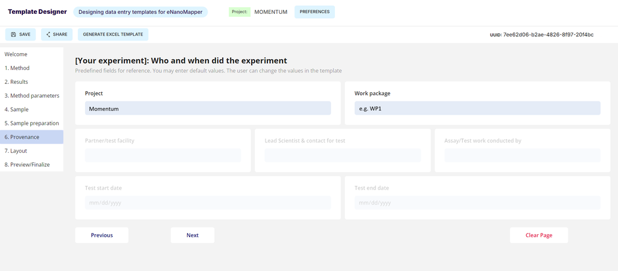

On this tab you can highlight which *project and work package* you are part of.

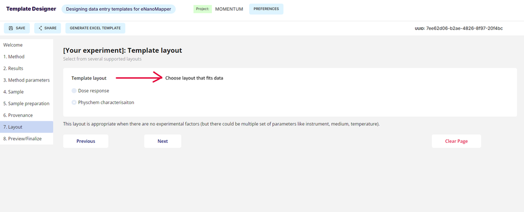

Choose a *layout* type.

- The *dose response* layout is appropriate when there are a number of experimental factors, e.g. concentration, time, as well as a single set of parameters like instrument, medium, temperature, cell type.
- The *physchem* layout is appropriate when there are no experimental factors (but there could be multiple set of parameters like instrument, medium, temperature).

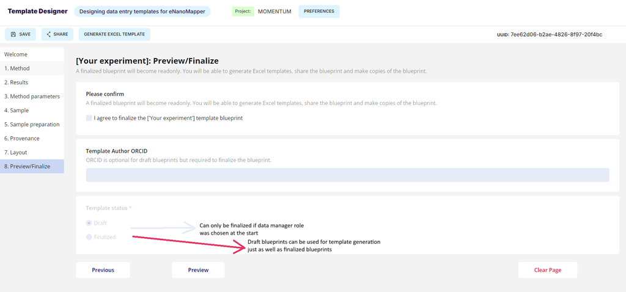

You can finalize your template if you chose a ‘data manager’ role on the first tab earlier. Alternatively, ask a data person to look at your draft template and finalize it for you.

This step is **not mandatory for having a functional template**. You can very well use draft templates as well. Click save.

Now your newly designed template should be available either under Finalized or Draft Blueprints in the Desinger.

**ImportantHelp to improve**

There can be bugs in the Designer, for instance an issue with generating a link to the template (check backslash, forward slash in copied urls). Please report such things [here](https://github.com/ideaconsult/templateforge/issues).

**TipGood to know**

Since the Desinger is still under development, new features are coming, for instance, the “Customize Excel template” option for blueprints.

Back to top